# Project#5 - Data Visualization

> **Developed By**: Rakan210 on June 27, 2019 - as part of Udacity Data Analyst Nanodegree program (DAND)"

## Preliminary Wrangling

> This dataset reports flights in the United States, including carriers, arrival and departure delays, and reasons for delays, from 1987 to 2008. The data comes originally from [RITA](https://www.transtats.bts.gov/OT_Delay/OT_DelayCause1.asp) where it is [described in detail](https://www.transtats.bts.gov/Fields.asp?Table_ID=236). These files have derivable variables removed, are packaged in yearly chunks and have been more heavily compressed than the originals.

### What is the structure of your dataset?

This **giant DataFrame** has **[123,534,969]** entries (rows) each with **[29]** variables (columns).

**# Variable descriptions** s|Name | Description --- | :-: | :-: 1|Year | 1987-2008 2|Month | 1-12 3|DayofMonth|1-31 4|DayOfWeek|1 (Monday) - 7 (Sunday) 5|DepTime|actual departure time (local, hhmm) 6|CRSDepTime|scheduled departure time (local, hhmm) 7|ArrTime|actual arrival time (local, hhmm) 8|CRSArrTime|scheduled arrival time (local, hhmm) 9|UniqueCarrier|[unique carrier code](http://stat-computing.org/dataexpo/2009/supplemental-data.html) 10|FlightNum|flight number 11|TailNum|plane tail number 12|ActualElapsedTime|in minutes 13|CRSElapsedTime|in minutes 14|AirTime|in minutes 15|ArrDelay|arrival delay, in minutes 16|DepDelay|departure delay, in minutes 17|Origin|origin [IATA airport code](http://stat-computing.org/dataexpo/2009/supplemental-data.html) 18|Dest|destination [IATA airport code](http://stat-computing.org/dataexpo/2009/supplemental-data.html) 19|Distance|in miles 20|TaxiIn|taxi in time, in minutes 21|TaxiOut|taxi out time in minutes 22|Cancelled|was the flight cancelled? 23|CancellationCode|reason for cancellation (A = carrier, B = weather, C = NAS, D = security) 24|Diverted|1 = yes, 0 = no 25|CarrierDelay|in minutes 26|WeatherDelay|in minutes 27|NASDelay|in minutes 28|SecurityDelay|in minutes 29|LateAircraftDelay|in minutes

### What is/are the main feature(s) of interest in your dataset?

> - How the total number of flights has been changed over the years?
> - Which airlines operate more flights and how this has been changed over the years?
> - Is there a relation between the number of operated flights and the total delay time?
> - What are the critical periods of the year that has the most recorded delays?
> - How the Departure delay is affecting the Arrival Delay?
> - How much time delayed by each delay cause? and how this is related to the number of flights?

### What features in the dataset do you think will help support your investigation into your feature(s) of interest?

> - As the dataset has a dedicated columns that show the actual delay in minutes for both Arrival and Departure, this will be very useful to study the delay times from different aspects. This was planed to be calculated anyhow.
> - Time factors including: Year, Month and Days.
> - Delay causes.
> - Cancellation status.

### Preparing data:

> first, we need to clean the dataset by removing unrequired columns and preparing sub-dataset to speedup the processing time.

> **Unrequired columns are:**
> - CRSDepTime
> - CRSArrTime
> - FlightNum
> - TailNum
> - ActualElapsedTime
> - CRSElapsedTime
> - AirTime
> - TaxiIn
> - TaxiOut

> **Things to consider:**
> - Cancellation Code and Cuases were not recorded before 2002
> - TailNum, AirTime, TaxiIn, TaxiOut values were not recorded before 1994

```python
# Delete unrequired columns:
columns = ['CRSDepTime','CRSArrTime','CRSArrTime','TailNum', 'FlightNum', 'ActualElapsedTime',
           'CRSElapsedTime', 'AirTime', 'TaxiIn','TaxiOut']
df_flights.drop(columns,axis=1,inplace=True)

# Add Total_Delay column that indicate the total delay for each flight:
df_flights.insert(9, 'total_delay', df_flights.ArrDelay + df_flights.DepDelay)

# Rename [DayofMonth] column:
df_flights.rename(columns={'DayofMonth': 'DayOfMonth'}, inplace=True)
```

```python
df_flights.info()
```

```
<class 'pandas.core.frame.DataFrame'>
Int64Index: 123534969 entries, 0 to 7009727
Data columns (total 21 columns):
Year                 int64
Month                int64
DayOfMonth           int64
DayOfWeek            int64
DepTime              float64
ArrTime              float64
UniqueCarrier        object
ArrDelay             float64
DepDelay             float64
total_delay          float64
Origin               object
Dest                 object
Distance             float64
Cancelled            int64
CancellationCode     object
Diverted             int64
CarrierDelay         float64
WeatherDelay         float64
NASDelay             float64
SecurityDelay        float64
LateAircraftDelay    float64
dtypes: float64(11), int64(6), object(4)
memory usage: 20.2+ GB
```

## Univariate Exploration

> In this section, investigate distributions of individual variables. If you see unusual points or outliers, take a deeper look to clean things up and prepare yourself to look at relationships between variables.

> Let's have a look to the main variables in the dataset to see if there are any unusual points or outliers.

#### 1. Flights Overview:

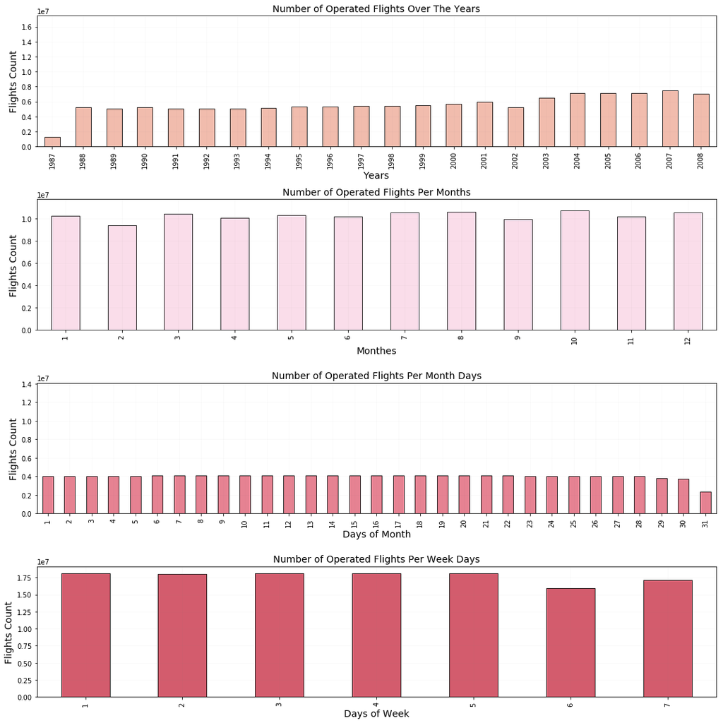

```python
# Function to plot a bar graph for a given dataframe with certain formate:
def plotGraph(df, graphSize, barColor, edgeColor, a, title, xLbl, yLbl, fontSize, ylim):
    graph = df.plot(kind='bar', figsize=(graphSize, graphSize), ylim=ylim, alpha=a, color=barColor ,edgecolor=edgeColor)
    graph.set_title(title, size= fontSize)
    graph.set_xlabel(xLbl, size = fontSize)
    graph.set_ylabel(yLbl, size = fontSize)
    graph.grid(True, which='major', color='gray', alpha=0.05);
    return graph


plt.subplot(411)
yearly_plt = plotGraph(flights_count_yearly, 15, '#eeac99', 'black', 0.8, 'Number of Operated Flights Over The Years',
                       'Years','Flights Count', 14, (0,flights_count_yearly.max()+1e7))

plt.subplot(412)
months = ['January', 'February', 'March', 'April', 'May', 'June', 'July', 'August','September', 'October', 'November', 'December']
monthly_plt = plotGraph(flights_count_monthly, 15, '#f9d5e5', 'black', 0.8,'Number of Operated Flights Per Months',
                        'Monthes','Flights Count',14, (0,flights_count_monthly.max()+1e6))
# monthly_plt.set_xticklabels(months, size = 14, labelpad=20)

plt.subplot(413)
dom_plt = plotGraph(flights_count_dom, 15, '#e06377', 'black', 0.8,'Number of Operated Flights Per Month Days',
                        'Days of Month','Flights Count',14, (0,flights_count_dom.max()+1e7))

plt.subplot(414)
days = ['Monday', 'Tuesday', 'Wednesday', 'Thursday', 'Friday', 'Saturday', 'Sunday']
dom_plt = plotGraph(flights_count_dow, 15, '#c83349', 'black', 0.8,'Number of Operated Flights Per Week Days',
                        'Days of Week','Flights Count',14, (0,flights_count_dow.max()+1e6))
# dow_plt.set_xticklabels(days, size = 14)

plt.tight_layout()
```

**Days of week: 1 = Monday --> 7 = Sunday**

**#1# How the total number of flights has been changed over the years?**

**#2# What are the critical periods of the year that has the most recorded delays?**

#### 2. Arilines (Carrier) Overview:

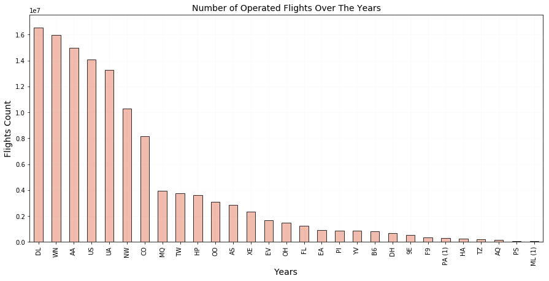

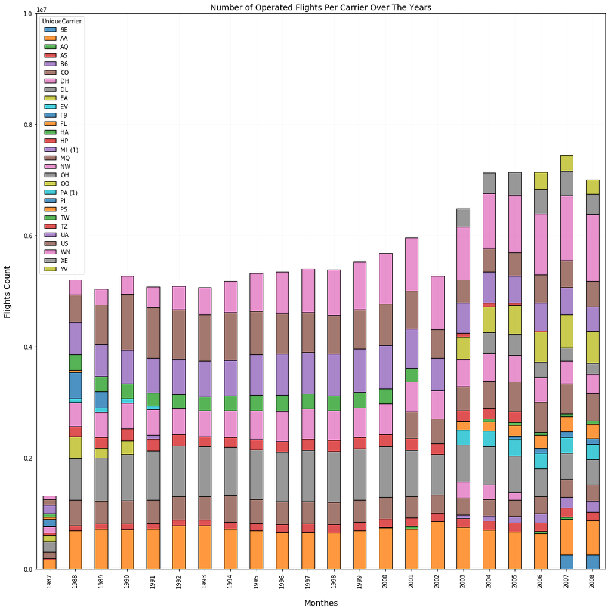

```python
plt.subplot(211)

carrier_flights_count= carrier_flights_count.sort_values(ascending=False)
carrier_yearly_plt = plotGraph(carrier_flights_count, 15, '#eeac99', 'black', 0.8,'Number of Operated Flights Over The Years',
                        'Years','Flights Count',14, (0,carrier_flights_count.max()+1e6));

carrier_yearly2_plt = carrier_flights_count_yearly.plot(kind='bar', stacked=True, figsize=(15,15), alpha=0.8 ,edgecolor='black', ylim=(0,1e7))
carrier_yearly2_plt.set_title('Number of Operated Flights Per Carrier Over The Years', size = 14)
carrier_yearly2_plt.set_xlabel('Monthes', size = 14, labelpad=20)
carrier_yearly2_plt.set_ylabel('Flights Count', size = 14, labelpad=20)
carrier_yearly2_plt.grid(True, which='major', color='gray', alpha=0.05);

plt.tight_layout()
```

**#3# Which airlines operate more flights and how this has been changed over the years?**

What really caught my eyes is what happened in **2002**?! There is a slight drop in the number of flights with almost **[700K]** flights and some carriers, such as **("AQ","Aloha Airlines Inc.")** were disappeared!! Searching the company [Wiki's page](https://en.wikipedia.org/wiki/Aloha_Airlines) attributed this to what happened in [September 2001](https://en.wikipedia.org/wiki/September_11_attacks).

**#Note:** More info about hte carrires: [unique carrier code](http://stat-computing.org/dataexpo/2009/supplemental-data.html)

#### 3. Delay Overview:

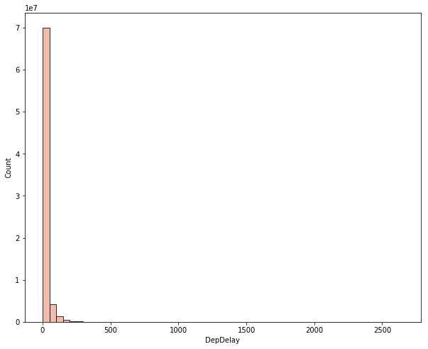

```python
binsize = 50
bins = np.arange(0, df_flights['DepDelay'].max()+binsize, binsize)
plt.figure(figsize=[10, 8])
plt.hist(data= df_flights, x= 'DepDelay', bins= bins, alpha=0.8, color='#eeac99' ,edgecolor='black')
plt.xlabel('DepDelay')
plt.ylabel('Count')
plt.show()
```

Above graph shows there's a long tail in the distribution of flight departue delay. This required some modification to clarify the graph.

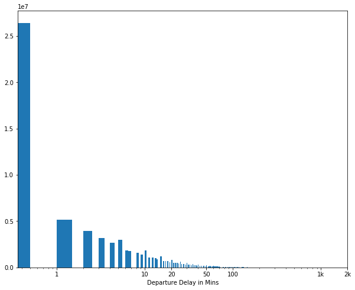

```python
log_binsize = 0.005
bins =  100* np.arange(0, np.log10(df_flights['DepDelay'].max())+log_binsize, log_binsize)
plt.figure(figsize=[10, 8])
plt.hist(data= df_flights, x='DepDelay', bins= bins)
plt.xlabel('Departure Delay in Mins')
plt.xscale('log')
plt.xticks([1,10,20,50,100,1e3,2e3],[1,10,20,50,100,'1k','2k'])
plt.show()
```

The graph now is clearer and has a better representation for the delayed time. However, there some flights that have been delyed for more than a day. This is in terms of either Departure or Arraivale times. Details are provided below:

```python
outliers = (df_flights['ArrDelay'] > 1440)
print('\n\nNumber of outliers based on Arraival Time = [', outliers.sum(),']\n\n')
print(df_flights.loc[outliers,:])
```

```
Number of outliers based on Arraival Time = [ 80 ]


         Year  Month  DayOfMonth  DayOfWeek  DepTime  ArrTime UniqueCarrier  \
3324231  1997      8           2          6   1438.0   1957.0            NW
1479584  1998      4          24          5   1625.0   1908.0            NW
4291628  1998     10           9          5   1505.0   1722.0            NW
166173   1999      1           2          6   1210.0   1325.0            NW
260228   1999      1           3          7   1601.0   2236.0            NW
5321057  1999     12           9          4   1100.0   1302.0            NW
5061704  2000     11          19          7   2400.0    542.0            NW
139008   2001      1           6          6   1501.0   1741.0            NW
147775   2001      1           8          1   1929.0    650.0            NW
147786   2001      1          19          5   2242.0   1012.0            NW
882738   2001      2           3          6   2355.0    540.0            NW
```

[output cut: 241 more lines]

```python
outliers = (df_flights['DepDelay'] > 1440)
print('\n\nNumber of outliers based on Departure Time = [', outliers.sum(),']\n\n')
print(df_flights.loc[outliers,:]);
```

```
Number of outliers based on Departure Time = [ 75 ]


         Year  Month  DayOfMonth  DayOfWeek  DepTime  ArrTime UniqueCarrier  \
4620568  1989     12          30          6   1041.0      NaN            US
3324231  1997      8           2          6   1438.0   1957.0            NW
1479584  1998      4          24          5   1625.0   1908.0            NW
4291628  1998     10           9          5   1505.0   1722.0            NW
145730   1999      1           9          6    704.0    757.0            NW
166173   1999      1           2          6   1210.0   1325.0            NW
260228   1999      1           3          7   1601.0   2236.0            NW
5321057  1999     12           9          4   1100.0   1302.0            NW
139008   2001      1           6          6   1501.0   1741.0            NW
147775   2001      1           8          1   1929.0    650.0            NW
147786   2001      1          19          5   2242.0   1012.0            NW
```

[output cut: 241 more lines]

#### 4. Delays and Cancellation Overview:

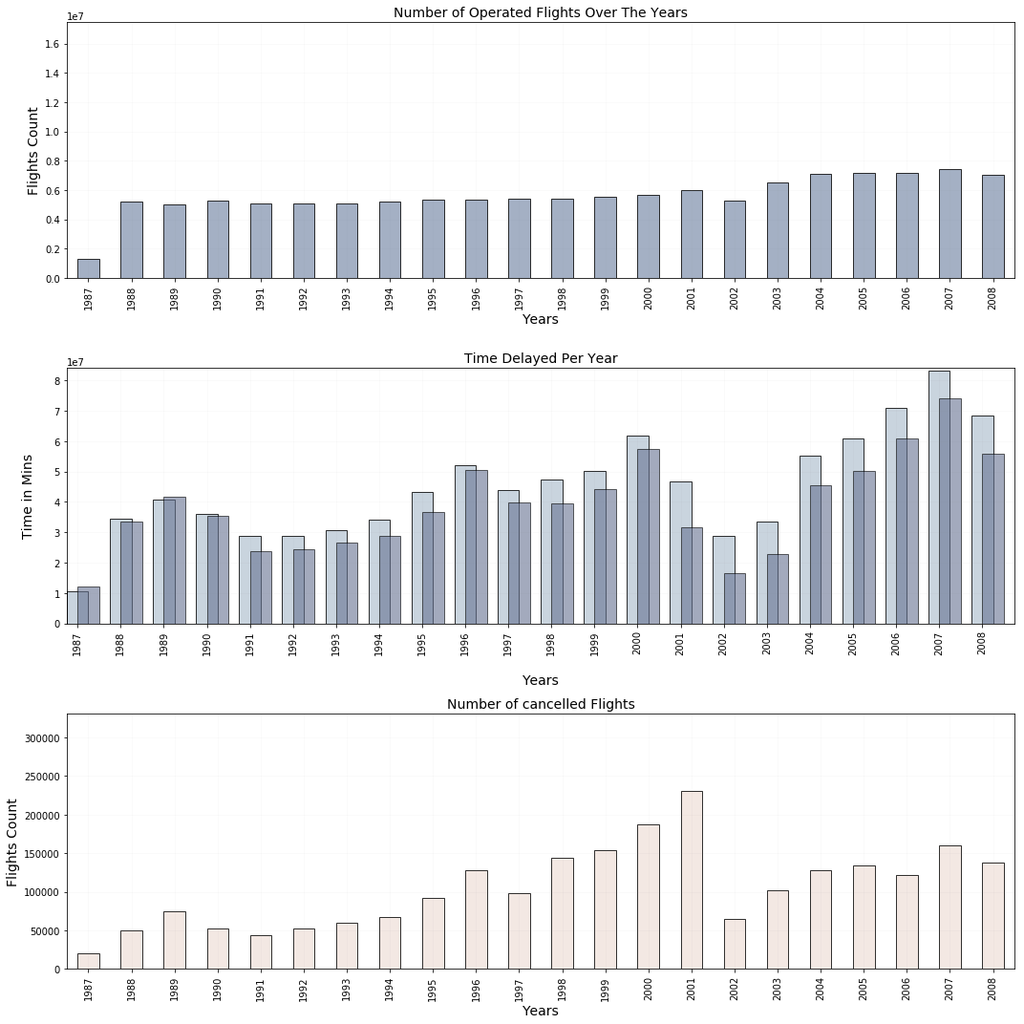

```python
# Plot-311: Number of Operated Flights Over The Years:
plt.subplot(311)
count_plt = plotGraph(flights_count_yearly, 15, '#8d9db6', 'black', 0.8,'Number of Operated Flights Over The Years',
                        'Years','Flights Count',14, (0,flights_count_yearly.max()+1e7))

# Plot-312A: Departure Time Delayed Per Year:
plt.subplot(312)
flights_delay_yearly = df_flights.groupby('Year')['DepDelay'].sum()
delay_plt = plotGraph(flights_delay_yearly, 15, '#bccad6', 'black', 0.8, 'Time Delayed Per Year',
                        'Years','Time in Mins',14, (0,flights_delay_yearly.max()+1e7))

# Plot-312B: Arraival Time Delayed Per Year:
plt.subplot(312)
flights_array_yearly = df_flights.groupby('Year')['ArrDelay'].sum()
delay_plt = flights_array_yearly.plot(kind='bar', figsize=(15,15), alpha=0.6, color='#667292' , align = 'edge',
                                       edgecolor='black', ylim=(0,flights_array_yearly.max()+1e7))
delay_plt.set_title('Time Delayed Per Year', size = 14)
delay_plt.set_xlabel('Years', size = 14, labelpad=20)
delay_plt.set_ylabel('Time in Mins', size = 14, labelpad=20)
delay_plt.grid(True, which='major', color='gray', alpha=0.05);

# Plot-313: Number of cancelled Flights:
plt.subplot(313)
cancelle_plt = plotGraph(flights_cancelled_count, 15, '#f1e3dd', 'black', 0.8, 'Number of cancelled Flights',
                        'Years','Flights Count',14, (0,flights_cancelled_count.max()+1e5))

plt.tight_layout()
```

**#4# Is there a relation between the number of operated flights and the total delay time?**

Above graphs show direct correlation between number of flights, delay time and cancelation rate over the years.

### Discuss the distribution(s) of your variable(s) of interest. Were there any unusual points? Did you need to perform any transformations?

> As stated before, in general, over the years the number of flights increased constantly. The same applys withdelay time and cancelation rate. Except in 2002, a notible drop has been noticed and this is due an controled causes. Studying the delay time has also an interesting findings in which almost 150 flight were delayed for over a day, which reflects on the hist graph as a long tail on the right side of the graph. This required me to change the scale of the graph to be a Logarithmic scale to represent the data in a better form.

## Bivariate Exploration

> In this section, investigate relationships between pairs of variables in your data. Make sure the variables that you cover here have been introduced in some fashion in the previous section (univariate exploration).

```python
# Define all numarical values in the dataset:

numeric_vars = ['Year', 'Month', 'DayOfMonth', 'DayOfWeek', 'DepTime', 'ArrTime', 'ArrDelay','DepDelay',
                'total_delay', 'Distance', 'Cancelled','Diverted', 'CarrierDelay', 'WeatherDelay','NASDelay',
                'SecurityDelay', 'LateAircraftDelay']

# Define all categorical values in the dataset:
categoric_vars = ['UniqueCarrier', 'Origin', 'Dest', 'CancellationCode']
```

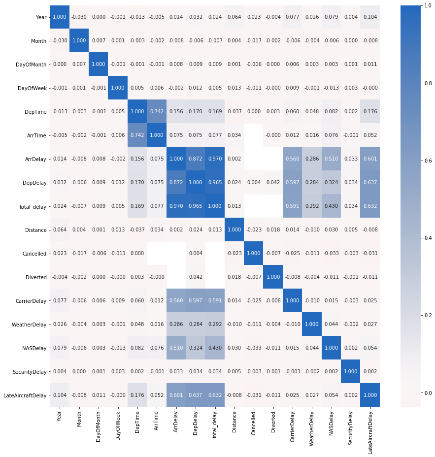

```python
# Plot a correlation heatmap between all numarical vareibles:
plt.figure(figsize = [15, 15])
sb.heatmap(df_flights[numeric_vars].corr(), annot= True, fmt= '.3f', cmap= 'vlag_r', center= 0)
plt.show()
```

Lets know have a detailed visualization for a sample of each variables to see how they are correlated. The idea of having a sample instead of using the whole population is to make the plotting much faster and clearer.

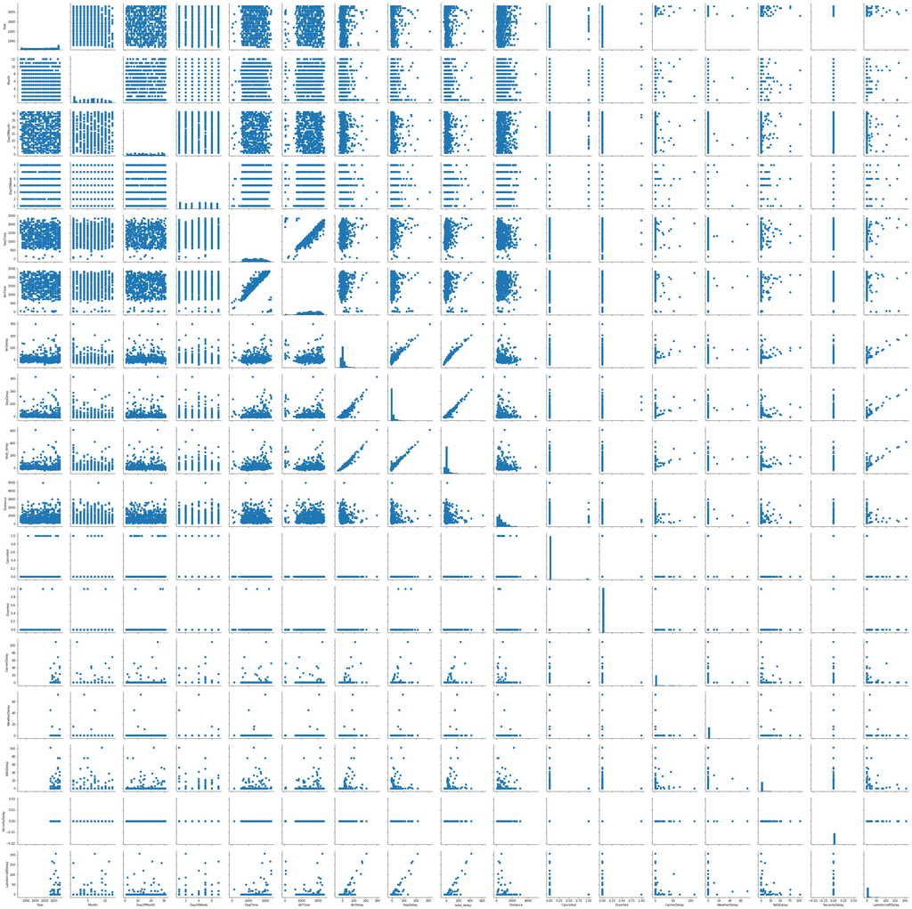

```python
# Matrix plotting:
# Sampling for faster and clearer
samples = np.random.choice(df_flights.shape[0], 500, replace = False)
flights_sample = df_flights[numeric_vars].loc[samples,:]

# correlation plot for all numaric
grid_graph = sb.PairGrid(data= flights_sample, vars= numeric_vars)
grid_graph = grid_graph.map_diag(plt.hist, bins= 20);
grid_graph.map_offdiag(plt.scatter)
```

As shown above, many of the variables are uniformly distributed with each other. Let's focused on the others as they are much correlated.

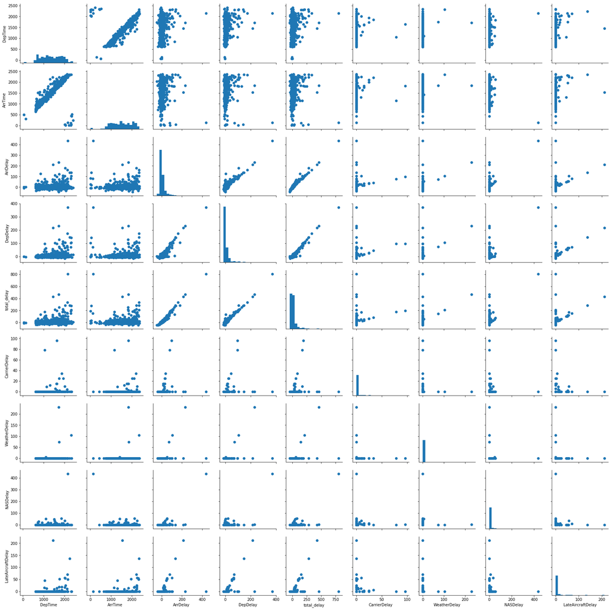

```python
# Matrix plotting:

correlated_numeric_vars = ['DepTime', 'ArrTime', 'ArrDelay','DepDelay', 'total_delay',
                           'CarrierDelay', 'WeatherDelay','NASDelay', 'LateAircraftDelay']

# Sampling for faster and clearer
samples = np.random.choice(df_flights.shape[0], 500, replace = False)
flights_sample = df_flights[correlated_numeric_vars].loc[samples,:]

# correlation plot
grid_graph = sb.PairGrid(data= flights_sample, vars= correlated_numeric_vars)
grid_graph = grid_graph.map_diag(plt.hist, bins= 20)
grid_graph.map_offdiag(plt.scatter);
```

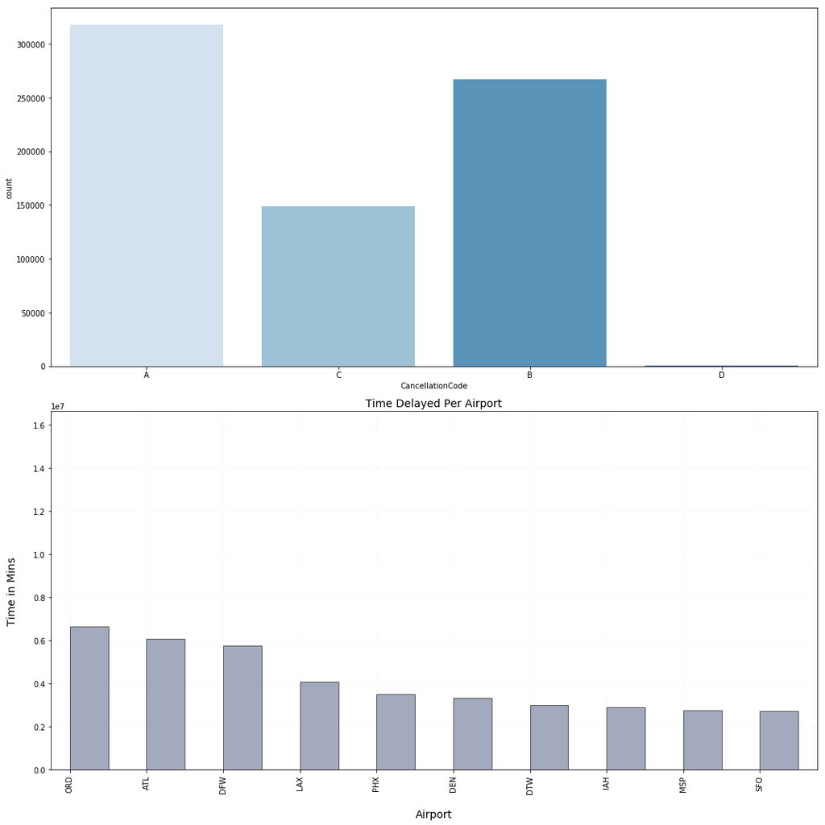

```python
# since there's only three subplots to create, using the full data should be fine.
plt.figure(figsize = [15, 15])

# subplot 1: color vs cut
plt.subplot(211)
sb.countplot(data= df_flights, x= 'CancellationCode', palette = 'Blues')

plt.subplot(212)
count_plt = flights_dest_count.plot(kind='bar', figsize=(15,15), alpha=0.6, color='#667292' , align = 'edge',
                                       edgecolor='black', ylim=(0,flights_dest_count.max()+1e7))
count_plt.set_title('Time Delayed Per Airport', size = 14)
count_plt.set_xlabel('Airport', size = 14, labelpad=20)
count_plt.set_ylabel('Time in Mins', size = 14, labelpad=20)
count_plt.grid(True, which='major', color='gray', alpha=0.05);

plt.tight_layout()
```

**Note: Cancellation Codes:**

- A = carrier
- B = weather
- C = NAS
- D = security

### Talk about some of the relationships you observed in this part of the investigation. How did the feature(s) of interest vary with other features in the dataset?

> An approximately linear relationship was observed when plotting scattered plot to illustrate the correlation between Departure delay and Arrival delay, which make sense as the flight will arrive late once there are some issue while take-off. Also, It has been noticed that the main cause of delay in world of aviation is usually the carriers, that followed by the weather as second main cause of flights cancellation. Moreover, as most of the flights have been managed to be operated on the scheduled time, many graphs showed a stable performance and anomalies where easy to be detected.

### Did you observe any interesting relationships between the other features (not the main feature(s) of interest)?

> Not to much.

## Multivariate Exploration

```python
# Sampling for faster and clearer
samples = np.random.choice(df_flights.shape[0], 500, replace = False)
flights_sample = df_flights.loc[samples,:]
```

[figure not shown]

```python
# correlation plot
graph = sb.FacetGrid(data= flights_sample, hue='UniqueCarrier', size=10 )
graph = graph.map(sb.regplot,'DepDelay', 'CarrierDelay')
plt.title('Correlation Between Departure Time and Carreir Delay')
plt.xlabel('Departure Delay in Mins')
plt.ylabel('Cerrier Delay in Mins')
graph.add_legend();
```